# Grzegorz Krochmal and Katarzyna Kryńska

## *Prediction of LendingClub loan defaulters*

# Introduction

LendingClub is a US peer-to-peer lending company. LendingClub enables borrowers to create unsecured personal loans between \$500 and \\$40,000. Investors can choose which loans they want to invest in based on information about borrower, amount of loan, loan grade and loan purpose.

As loans are unsecured, it is crucial to assess whether the borrower will be able to pay their debt. Therefore our main goal is to correctly identify defaulters, so that LendingClub can conclude whether an applicant is fit for a loan in the future.

```python
import pandas as pd
import matplotlib.pyplot as plt
import seaborn as sns
import numpy as np
from sklearn.linear_model import LogisticRegression
from sklearn.model_selection import cross_val_predict
from sklearn.model_selection import train_test_split
from sklearn import preprocessing
from sklearn.model_selection import cross_val_score
from sklearn.metrics import accuracy_score
from sklearn.metrics import confusion_matrix as cm
from sklearn.model_selection import KFold
from sklearn import metrics
from sklearn.svm import SVC
import seaborn as sns
```

# 1. Data Overview

The dataset used in analysis includes loan data for all loans issued through 2007-2015, both those which already ended and current ones. It consists of more than 2 million observations (rows) and 145 variables (columns).

Firstly, we will have a look at the data.

```python
data = pd.read_csv("D:\WNE\lending-club-loan-data\loan.csv", low_memory=False)
#data = pd.read_csv(r"C:\Users\user\Desktop\studia\Data Science\Semestr 2\Python_ML\big_dataset\Lending_Club_Loan\loan.csv", low_memory=False)
```

```python
data.head(5)
```

|  | id | member_id | loan_amnt | funded_amnt | funded_amnt_inv | term | int_rate | installment | grade | sub_grade | ... | hardship_payoff_balance_amount | hardship_last_payment_amount | disbursement_method | debt_settlement_flag | debt_settlement_flag_date | settlement_status | settlement_date | settlement_amount | settlement_percentage | settlement_term |
| --- | --- | --- | --- | --- | --- | --- | --- | --- | --- | --- | --- | --- | --- | --- | --- | --- | --- | --- | --- | --- | --- |
| 0 | NaN | NaN | 2500 | 2500 | 2500.0 | 36 months | 13.56 | 84.92 | C | C1 | ... | NaN | NaN | Cash | N | NaN | NaN | NaN | NaN | NaN | NaN |
| 1 | NaN | NaN | 30000 | 30000 | 30000.0 | 60 months | 18.94 | 777.23 | D | D2 | ... | NaN | NaN | Cash | N | NaN | NaN | NaN | NaN | NaN | NaN |
| 2 | NaN | NaN | 5000 | 5000 | 5000.0 | 36 months | 17.97 | 180.69 | D | D1 | ... | NaN | NaN | Cash | N | NaN | NaN | NaN | NaN | NaN | NaN |
| 3 | NaN | NaN | 4000 | 4000 | 4000.0 | 36 months | 18.94 | 146.51 | D | D2 | ... | NaN | NaN | Cash | N | NaN | NaN | NaN | NaN | NaN | NaN |
| 4 | NaN | NaN | 30000 | 30000 | 30000.0 | 60 months | 16.14 | 731.78 | C | C4 | ... | NaN | NaN | Cash | N | NaN | NaN | NaN | NaN | NaN | NaN |

5 rows × 145 columns

Column names are not always clear, so we will keep column descriptions in variable *col_desc*.

```python
col_desc = pd.read_excel("LCDataDictionary.xlsx", sheet_name="LoanStats")
col_desc.head(5)
```

|  | LoanStatNew | Description |
| --- | --- | --- |
| 0 | acc_now_delinq | The number of accounts on which the borrower i... |
| 1 | acc_open_past_24mths | Number of trades opened in past 24 months. |
| 2 | addr_state | The state provided by the borrower in the loan... |
| 3 | all_util | Balance to credit limit on all trades |
| 4 | annual_inc | The self-reported annual income provided by th... |

Our explained variable is in column *loan_status*. We will now look what the column actually contains.

```python
data.loan_status.value_counts()
```

```
Fully Paid                                             1041952
Current                                                 919695
Charged Off                                             261655
Late (31-120 days)                                       21897
In Grace Period                                           8952
Late (16-30 days)                                         3737
Does not meet the credit policy. Status:Fully Paid        1988
Does not meet the credit policy. Status:Charged Off        761
Default                                                     31
Name: loan_status, dtype: int64
```

We are interested in loans that already finished (there are no more payments to be expected), so we will leave only rows in which the loan status is *Fully Paid* or *Default*. We will also concatenate *Charged Off* and *Default* as we believe clients who have the loan status *Charged Off* are just as big credit risk as those with default.

```python
data['loan_status'] = data['loan_status'].replace({'Charged Off':'Default'})
data = data[np.any([data.loan_status == 'Default', data.loan_status == 'Fully Paid'], axis=0)]
```

Now, we will look at distribution of loan status in our dataset.

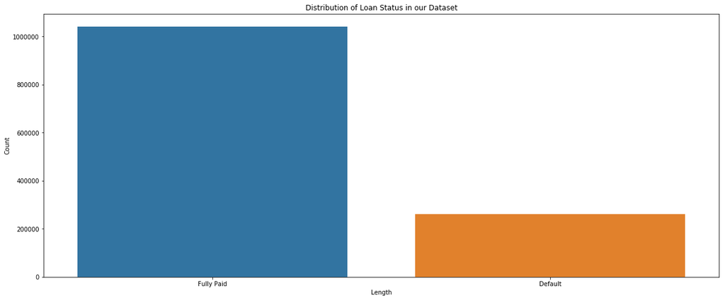

```python
m = data['loan_status'].value_counts()
m = m.to_frame()
m.reset_index(inplace=True)
m.columns = ['Loan Status','Count']
plt.subplots(figsize=(20,8))
sns.barplot(y='Count', x='Loan Status', data=m)
plt.xlabel("Length")
plt.ylabel("Count")
plt.title("Distribution of Loan Status in our Dataset")
plt.show()
```

Our data is clearly imbalanced. To deal with that problem, we could use over/undersampling. However, these methods do not always work and even if they do, they might work differently with different algorithms. Therefore we decided to leave the dataset as it is and we will see which method works the best for imbalanced data..

# 2. Data preparation

## 2.1. Data cleaning

Unfortunately, our dataset contains a lot of missing values. We will try now to deal with them.

```python
missings = pd.DataFrame({'Count': data.isnull().sum(), 'Percent': 100*data.isnull().sum()/len(data)})
missings['LoanStatNew'] = list(missings.index)
missings = missings.join(col_desc.set_index('LoanStatNew'), on='LoanStatNew')
missings = missings.drop(columns='LoanStatNew')
missings[missings['Percent'] > 10].sort_values(by=['Percent'], ascending=False)
```

|  | Count | Percent | Description |
| --- | --- | --- | --- |
| id | 1303638 | 100.000000 | A unique LC assigned ID for the loan listing. |
| url | 1303638 | 100.000000 | URL for the LC page with listing data. |
| member_id | 1303638 | 100.000000 | A unique LC assigned Id for the borrower member. |
| next_pymnt_d | 1303607 | 99.997622 | Next scheduled payment date |
| orig_projected_additional_accrued_interest | 1300205 | 99.736660 | The original projected additional interest amo... |
| hardship_last_payment_amount | 1298303 | 99.590761 | The last payment amount as of the hardship pla... |
| hardship_start_date | 1298303 | 99.590761 | The start date of the hardship plan period |
| hardship_type | 1298303 | 99.590761 | Describes the hardship plan offering |
| hardship_reason | 1298303 | 99.590761 | Describes the reason the hardship plan was off... |
| hardship_payoff_balance_amount | 1298303 | 99.590761 | The payoff balance amount as of the hardship p... |
| hardship_amount | 1298303 | 99.590761 | The interest payment that the borrower has com... |
| hardship_status | 1298303 | 99.590761 | Describes if the hardship plan is active, pend... |
| hardship_end_date | 1298303 | 99.590761 | The end date of the hardship plan period |
| payment_plan_start_date | 1298303 | 99.590761 | The day the first hardship plan payment is due... |
| hardship_length | 1298303 | 99.590761 | The number of months the borrower will make sm... |
| hardship_dpd | 1298303 | 99.590761 | Account days past due as of the hardship plan ... |
| hardship_loan_status | 1298303 | 99.590761 | Loan Status as of the hardship plan start date |
| deferral_term | 1298303 | 99.590761 | Amount of months that the borrower is expected... |
| sec_app_mths_since_last_major_derog | 1297702 | 99.544659 | NaN |
| sec_app_revol_util | 1287415 | 98.755559 | NaN |
| revol_bal_joint | 1287122 | 98.733084 | NaN |
| sec_app_collections_12_mths_ex_med | 1287121 | 98.733007 | NaN |
| sec_app_chargeoff_within_12_mths | 1287121 | 98.733007 | NaN |
| sec_app_num_rev_accts | 1287121 | 98.733007 | NaN |
| sec_app_open_act_il | 1287121 | 98.733007 | Number of currently active installment trades... |
| sec_app_open_acc | 1287121 | 98.733007 | NaN |
| sec_app_mort_acc | 1287121 | 98.733007 | NaN |
| sec_app_inq_last_6mths | 1287121 | 98.733007 | NaN |
| sec_app_earliest_cr_line | 1287121 | 98.733007 | NaN |
| verification_status_joint | 1280540 | 98.228189 | NaN |
| dti_joint | 1280396 | 98.217143 | A ratio calculated using the co-borrowers' tot... |
| annual_inc_joint | 1280394 | 98.216990 | The combined self-reported annual income provi... |
| settlement_term | 1271645 | 97.545868 | The number of months that the borrower will be... |
| settlement_percentage | 1271645 | 97.545868 | The settlement amount as a percentage of the p... |
| settlement_amount | 1271645 | 97.545868 | The loan amount that the borrower has agreed t... |
| settlement_date | 1271645 | 97.545868 | The date that the borrower agrees to the settl... |
| settlement_status | 1271645 | 97.545868 | The status of the borrower’s settlement plan. ... |
| debt_settlement_flag_date | 1271645 | 97.545868 | The most recent date that the Debt_Settlement_... |
| desc | 1180311 | 90.539782 | Loan description provided by the borrower |
| mths_since_last_record | 1081865 | 82.988145 | The number of months since the last public rec... |
| mths_since_recent_bc_dlq | 994481 | 76.285058 | Months since most recent bankcard delinquency |
| mths_since_last_major_derog | 961259 | 73.736651 | Months since most recent 90-day or worse rating |
| il_util | 870943 | 66.808654 | Ratio of total current balance to high credit/... |
| mths_since_recent_revol_delinq | 867789 | 66.566716 | Months since most recent revolving delinquency. |
| mths_since_rcnt_il | 817059 | 62.675298 | Months since most recent installment accounts ... |
| all_util | 804113 | 61.682231 | Balance to credit limit on all trades |
| open_acc_6m | 804063 | 61.678395 | Number of open trades in last 6 months |
| total_cu_tl | 804063 | 61.678395 | Number of finance trades |
| inq_last_12m | 804063 | 61.678395 | Number of credit inquiries in past 12 months |
| open_il_12m | 804062 | 61.678319 | Number of installment accounts opened in past ... |
| open_il_24m | 804062 | 61.678319 | Number of installment accounts opened in past ... |
| total_bal_il | 804062 | 61.678319 | Total current balance of all installment accounts |
| open_rv_12m | 804062 | 61.678319 | Number of revolving trades opened in past 12 m... |
| open_rv_24m | 804062 | 61.678319 | Number of revolving trades opened in past 24 m... |
| max_bal_bc | 804062 | 61.678319 | Maximum current balance owed on all revolving ... |
| inq_fi | 804062 | 61.678319 | Number of personal finance inquiries |
| open_act_il | 804062 | 61.678319 | Number of currently active installment trades |
| mths_since_last_delinq | 657833 | 50.461324 | The number of months since the borrower's last... |
| mths_since_recent_inq | 169552 | 13.006065 | Months since most recent inquiry. |

Firstly, we will fill in the columns *hardship_status* and *hardship_reason* as no data there means that there was no hardship plan.

```python
data.hardship_status = data.hardship_status.fillna("NO_HARDSHIP")
data.hardship_reason = data.hardship_reason.fillna("NO_HARDSHIP")
```

```python
pd.crosstab(data.hardship_status, data.loan_status)
```

| loan_status hardship_status | Default | Fully Paid |
| --- | --- | --- |
| ACTIVE | 1 | 0 |
| BROKEN | 1813 | 89 |
| COMPLETED | 2003 | 1429 |
| NO_HARDSHIP | 257869 | 1040434 |

```python
pd.crosstab(data.hardship_reason, data.loan_status)
```

| loan_status hardship_reason | Default | Fully Paid |
| --- | --- | --- |
| DISABILITY | 69 | 19 |
| DIVORCE | 106 | 27 |
| EXCESSIVE_OBLIGATIONS | 758 | 229 |
| FAMILY_DEATH | 65 | 27 |
| INCOME_CURTAILMENT | 513 | 121 |
| MEDICAL | 474 | 132 |
| NATURAL_DISASTER | 739 | 767 |
| NO_HARDSHIP | 257869 | 1040434 |
| REDUCED_HOURS | 254 | 56 |
| UNEMPLOYMENT | 839 | 140 |

We can see that hardship status and hardship reason might be an important factor in assessing whether someone is a defaulter. Fortunately, having filled the blanks, we will be able to use that in our analysis.

However, that still leaves us with a lot of missing data. We decided to drop columns where missing data is more than 10% as it is difficult to impute data when there are so many missing (for most of to-be-deleted columns the frequency of Nas is more than 95%!).

```python
data1 = data.dropna(axis=1, thresh=int(0.90*len(data))).copy()
```

```python
data1.head(5)
```

|  | loan_amnt | funded_amnt | funded_amnt_inv | term | int_rate | installment | grade | sub_grade | emp_title | emp_length | ... | tax_liens | tot_hi_cred_lim | total_bal_ex_mort | total_bc_limit | total_il_high_credit_limit | hardship_flag | hardship_reason | hardship_status | disbursement_method | debt_settlement_flag |
| --- | --- | --- | --- | --- | --- | --- | --- | --- | --- | --- | --- | --- | --- | --- | --- | --- | --- | --- | --- | --- | --- |
| 100 | 30000 | 30000 | 30000.0 | 36 months | 22.35 | 1151.16 | D | D5 | Supervisor | 5 years | ... | 0.0 | 527120.0 | 98453.0 | 28600.0 | 101984.0 | N | NO_HARDSHIP | NO_HARDSHIP | Cash | N |
| 152 | 40000 | 40000 | 40000.0 | 60 months | 16.14 | 975.71 | C | C4 | Assistant to the Treasurer (Payroll) | < 1 year | ... | 0.0 | 344802.0 | 161720.0 | 45700.0 | 167965.0 | N | NO_HARDSHIP | NO_HARDSHIP | Cash | N |
| 170 | 20000 | 20000 | 20000.0 | 36 months | 7.56 | 622.68 | A | A3 | Teacher | 10+ years | ... | 0.0 | 622183.0 | 71569.0 | 85100.0 | 74833.0 | N | NO_HARDSHIP | NO_HARDSHIP | Cash | N |
| 186 | 4500 | 4500 | 4500.0 | 36 months | 11.31 | 147.99 | B | B3 | Accounts Examiner III | 10+ years | ... | 0.0 | 53795.0 | 29137.0 | 15100.0 | 24595.0 | N | NO_HARDSHIP | NO_HARDSHIP | Cash | N |
| 215 | 8425 | 8425 | 8425.0 | 36 months | 27.27 | 345.18 | E | E5 | Senior Director Risk Management | 3 years | ... | 0.0 | 768304.0 | 189194.0 | 45800.0 | 189054.0 | N | NO_HARDSHIP | NO_HARDSHIP | Cash | N |

5 rows × 88 columns

Let's check how many rows with at least one missing value there are left.

```python
nan_rows = data1.isnull().sum(axis = 1)
nan_rows[nan_rows>0].count()
```

```
247369
```

Before we remove any rows, we will check the correlation matrix as some of the variables might be very strongly correlated and therefore we could remove one of them.

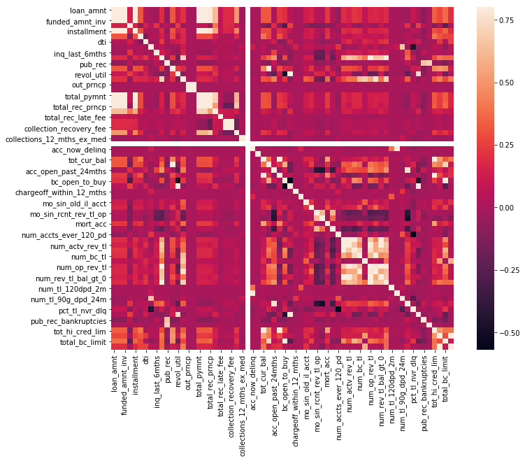

```python
corrmat = data1.corr()
f, ax = plt.subplots(figsize=(12, 9))
sns.heatmap(corrmat, vmax=.8, square=True);
```

Let's have a look through the most correlated variables.

1. Num_sats (Number of satisfactory accounts) and open_acc (The number of open credit lines in the borrower's credit file) - We believe they concain almost the same information and we will drop num_sats.
2. Funded_amnt, funded_amnt_inv and loan_amnt - the correlation is very big, so we will drop funded_amnt and funded_amnt_inv

Additionally, policy code is 1 all the time - it does not bring any information. We will also drop this column.

```python
data1.drop(columns = ['funded_amnt', 'funded_amnt_inv', 'num_sats', 'policy_code'], inplace = True)
```

Now we will look at the rest of missing data.

```python
missings = pd.DataFrame({'Count': data1.isnull().sum(), 'Percent': 100*data1.isnull().sum()/len(data)})
missings['LoanStatNew'] = list(missings.index)
missings = missings.join(col_desc.set_index('LoanStatNew'), on='LoanStatNew')
missings = missings.drop(columns='LoanStatNew')
missings[missings.Percent > 0]
```

|  | Count | Percent | Description |
| --- | --- | --- | --- |
| emp_title | 82582 | 6.334734 | The job title supplied by the Borrower when ap... |
| emp_length | 75457 | 5.788187 | Employment length in years. Possible values ar... |
| title | 15426 | 1.183304 | The loan title provided by the borrower |
| zip_code | 1 | 0.000077 | The first 3 numbers of the zip code provided b... |
| dti | 312 | 0.023933 | A ratio calculated using the borrower’s total ... |
| inq_last_6mths | 1 | 0.000077 | The number of inquiries in past 6 months (excl... |
| revol_util | 810 | 0.062134 | Revolving line utilization rate, or the amount... |
| last_pymnt_d | 2261 | 0.173438 | Last month payment was received |
| last_credit_pull_d | 54 | 0.004142 | The most recent month LC pulled credit for thi... |
| collections_12_mths_ex_med | 56 | 0.004296 | Number of collections in 12 months excluding m... |
| tot_coll_amt | 67527 | 5.179889 | Total collection amounts ever owed |
| tot_cur_bal | 67527 | 5.179889 | Total current balance of all accounts |
| total_rev_hi_lim | 67527 | 5.179889 | NaN |
| acc_open_past_24mths | 47281 | 3.626850 | Number of trades opened in past 24 months. |
| avg_cur_bal | 67548 | 5.181500 | Average current balance of all accounts |
| bc_open_to_buy | 60640 | 4.651598 | Total open to buy on revolving bankcards. |
| bc_util | 61387 | 4.708899 | Ratio of total current balance to high credit/... |
| chargeoff_within_12_mths | 56 | 0.004296 | Number of charge-offs within 12 months |
| mo_sin_old_il_acct | 104295 | 8.000304 | Months since oldest bank installment account o... |
| mo_sin_old_rev_tl_op | 67528 | 5.179966 | Months since oldest revolving account opened |
| mo_sin_rcnt_rev_tl_op | 67528 | 5.179966 | Months since most recent revolving account opened |
| mo_sin_rcnt_tl | 67527 | 5.179889 | Months since most recent account opened |
| mort_acc | 47281 | 3.626850 | Number of mortgage accounts. |
| mths_since_recent_bc | 59742 | 4.582714 | Months since most recent bankcard account opened. |
| num_accts_ever_120_pd | 67527 | 5.179889 | Number of accounts ever 120 or more days past due |
| num_actv_bc_tl | 67527 | 5.179889 | Number of currently active bankcard accounts |
| num_actv_rev_tl | 67527 | 5.179889 | Number of currently active revolving trades |
| num_bc_sats | 55841 | 4.283474 | Number of satisfactory bankcard accounts |
| num_bc_tl | 67527 | 5.179889 | Number of bankcard accounts |
| num_il_tl | 67527 | 5.179889 | Number of installment accounts |
| num_op_rev_tl | 67527 | 5.179889 | Number of open revolving accounts |
| num_rev_accts | 67528 | 5.179966 | Number of revolving accounts |
| num_rev_tl_bal_gt_0 | 67527 | 5.179889 | Number of revolving trades with balance >0 |
| num_tl_120dpd_2m | 115571 | 8.865268 | Number of accounts currently 120 days past due... |
| num_tl_30dpd | 67527 | 5.179889 | Number of accounts currently 30 days past due ... |
| num_tl_90g_dpd_24m | 67527 | 5.179889 | Number of accounts 90 or more days past due in... |
| num_tl_op_past_12m | 67527 | 5.179889 | Number of accounts opened in past 12 months |
| pct_tl_nvr_dlq | 67681 | 5.191702 | Percent of trades never delinquent |
| percent_bc_gt_75 | 61048 | 4.682895 | Percentage of all bankcard accounts > 75% of l... |
| pub_rec_bankruptcies | 697 | 0.053466 | Number of public record bankruptcies |
| tax_liens | 39 | 0.002992 | Number of tax liens |
| tot_hi_cred_lim | 67527 | 5.179889 | Total high credit/credit limit |
| total_bal_ex_mort | 47281 | 3.626850 | Total credit balance excluding mortgage |
| total_bc_limit | 47281 | 3.626850 | Total bankcard high credit/credit limit |
| total_il_high_credit_limit | 67527 | 5.179889 | Total installment high credit/credit limit |

Imputing data on that many rows and columns could take ages. As we have a lot of observations, we can just omit rows with missing data. We will check, however, if it changes our data imbalance.

```python
print(data1.loan_status.value_counts())
perc = data1.loan_status.value_counts()[1] / data1.loan_status.value_counts()[0]
print("Proportion Default/Fully Paid: %.2f" % perc)
```

```
Fully Paid    1041952
Default        261686
Name: loan_status, dtype: int64
Proportion Default/Fully Paid: 0.25
```

```python
data1.dropna(inplace = True)
print(data1.loan_status.value_counts())
perc = data1.loan_status.value_counts()[1] / data1.loan_status.value_counts()[0]
print("Proportion Default/Fully Paid: %.2f" % perc)
```

```
Fully Paid    851546
Default       204723
Name: loan_status, dtype: int64
Proportion Default/Fully Paid: 0.24
```

This operation did not change our dependent variable imbalance.

```python
data3 = data1.copy()
```

## 2.2. One Hot Encoding and Final Dataset

Before going further we have to encode categorical variables. To achieve that we will use one hot encoding

```python
levCols = []
numCols = []
for col in data3.columns:
    if data3[col].dtype==object:
        levCols.append(col)
    else:
        numCols.append(col)
```

```python
levCols.remove("loan_status")
```

### 2.2.1. Dealing with categorical variables with many factors

Before moving to One Hot Encoding it would be useful to look at unique values of selected object-type variables. And how many levels they actually have.

```python
num_levels = {}

for levs in levCols:
    num_levels[levs] = len(list(data3[levs].unique()))
```

```python
sorted_num_levels = sorted(num_levels.items(), key=lambda kv: kv[1])
sorted_num_levels
```

```
[('pymnt_plan', 1),
 ('term', 2),
 ('initial_list_status', 2),
 ('application_type', 2),
 ('hardship_flag', 2),
 ('disbursement_method', 2),
 ('debt_settlement_flag', 2),
 ('verification_status', 3),
 ('hardship_status', 4),
 ('home_ownership', 6),
 ('grade', 7),
 ('hardship_reason', 10),
 ('emp_length', 11),
 ('purpose', 14),
 ('sub_grade', 35),
 ('addr_state', 51),
 ('issue_d', 77),
 ('last_pymnt_d', 78),
 ('last_credit_pull_d', 80),
 ('earliest_cr_line', 719),
 ('zip_code', 939),
 ('title', 35165),
 ('emp_title', 311102)]
```

So it is obvious that there is a serious problem we have to deal with. Using One Hot Encoding with this set of variables where some of them have many thousands levels would surely make our analysis almost impossible (actually we tried and finished with the dataset with 400k columns). Let's take a closer look at all the variables which have more than 10 levels. Those are:

**emp_length:**

```python
dict(data3.emp_length.value_counts())
```

```
{'10+ years': 373308,
 '2 years': 101084,
 '3 years': 89135,
 '< 1 year': 89099,
 '1 year': 72787,
 '5 years': 68734,
 '4 years': 65606,
 '6 years': 51725,
 '8 years': 51515,
 '7 years': 50080,
 '9 years': 43196}
```

In this case we can see that we have levels which are easy to distnigiush. We will encode labels as numerical

```python
dictt = {}
for k, v in dict(data3.emp_length.value_counts()).items():
    if "years" in k:
        new_key = k.replace("years", "")

        if "+" in new_key:
            new_key = new_key.replace("+", "")

        dictt[int(new_key)] = v

    else:
        new_key = k.replace("year", "")

        if "<" in new_key:
            new_key = 0

        dictt[int(new_key)] = v

keys = list(dict(data3.emp_length.value_counts()).keys())
values = list(dictt.keys())
fin = dict(zip(keys, values))
data3.emp_length.replace(fin, inplace = True)
levCols.remove("emp_length")
```

**purpose:**

```python
dict(data3.purpose.value_counts())
```

```
{'debt_consolidation': 623330,
 'credit_card': 233874,
 'home_improvement': 67256,
 'other': 57625,
 'major_purchase': 21560,
 'medical': 11612,
 'car': 10192,
 'small_business': 10131,
 'moving': 7099,
 'vacation': 6785,
 'house': 5378,
 'wedding': 778,
 'renewable_energy': 648,
 'educational': 1}
```

In this case changing the encoding to discrete one does not make much sense, cause next levels doesn't mean anything. In this case we will group the levels in an arbitrary way to limit the number of levels which will be later Hot Encoded

```python
dictt = {'debt_consolidation': 'debt_consolidation',
 'credit_card': 'credit_card',
 'vacation': 'credit_card',
 'home_improvement': 'home_improvement',
 'house': 'home_improvement',
 'moving': 'home_improvement',
 'other': 'other',
 'wedding': 'other',
 'renewable_energy':'other',
 'major_purchase': 'major_purchase',
 'medical': 'medical',
 'small_business': 'small_business',
 'car': "car",
 'educational': 'educational'}

data3.purpose.replace(dictt, inplace = True)
```

**sub_grade** In this case we have some levels from G to A with additional numerical scale. To limit number of levels we will get rid off additional numerical scale

```python
dict(data3.sub_grade.value_counts())
```

```
{'C1': 66850,
 'B4': 65489,
 'B3': 63659,
 'B5': 63647,
 'C2': 61541,
 'C3': 59686,
 'C4': 59347,
 'B2': 58661,
 'B1': 56781,
 'C5': 53525,
 'A5': 51493,
 'A4': 40444,
 'D1': 39869,
 'A1': 35267,
 'D2': 34217,
 'D3': 30086,
 'A3': 29833,
 'A2': 29650,
 'D4': 27361,
 'D5': 23190,
 'E1': 18366,
 'E2': 16674,
 'E3': 14415,
 'E4': 12345,
 'E5': 11355,
 'F1': 7781,
 'F2': 5589,
 'F3': 4800,
 'F4': 3877,
 'F5': 3172,
 'G1': 2358,
 'G2': 1698,
 'G3': 1303,
 'G4': 1034,
 'G5': 906}
```

```python
fin = {}
for k, v in dict(data3.sub_grade.value_counts()).items():
    fin[k] = k[0]
data3.sub_grade.replace(fin, inplace = True)
```

**addr_state** means the State where the borower lives. However it is hard to find a proper approach to deal with this variable. Grouping it might be a good option but it surely requires a deep research of particular states similarities. Therefore, to simplify our analysis we will drop this variable.

```python
# levCols.remove("addr_state")
data3.drop(columns="addr_state", inplace = True)
```

**last_credit_pull_d** this variable is in format month - year. To simplify analysis we will group it into years

```python
dict(data3.last_credit_pull_d.value_counts())
```

```
{'Feb-2019': 381617,
 'Jan-2019': 63007,
 'Jul-2018': 46280,
 'Dec-2018': 42260,
 'Oct-2018': 41427,
 'Nov-2018': 39158,
 'Oct-2016': 37801,
 'Aug-2018': 37118,
 'Sep-2018': 29223,
 'May-2018': 21598,
 'Feb-2017': 21466,
 'Apr-2018': 20775,
 'Mar-2018': 20174,
 'Jan-2018': 18265,
 'Feb-2018': 18042,
 'Oct-2017': 17743,
 'Nov-2017': 15488,
 'Dec-2017': 14044,
 'Aug-2017': 13650,
 'Sep-2017': 13432,
 'Jun-2017': 12982,
 'Jul-2017': 12252,
 'Mar-2017': 10746,
 'Apr-2017': 10025,
 'Jan-2017': 8871,
 'May-2017': 8520,
 'Jun-2018': 8011,
 'Dec-2016': 7391,
 'Nov-2016': 6110,
 'Jul-2016': 4066,
 'Apr-2016': 3979,
 'Aug-2016': 3923,
 'Mar-2016': 3701,
 'Feb-2016': 3489,
 'Jun-2016': 3207,
 'May-2016': 2897,
 'Jan-2016': 2648,
 'Dec-2015': 2547,
 'Oct-2015': 2293,
 'Sep-2015': 2293,
```

[output cut: 25 more lines]

```
 'Aug-2013': 171,
 'Sep-2013': 168,
 'Jul-2013': 166,
 'May-2013': 116,
 'Jun-2013': 102,
 'Mar-2013': 86,
 'Feb-2013': 82,
 'Apr-2013': 78,
 'Dec-2012': 34,
 'Nov-2012': 26,
 'Jan-2013': 13,
 'Oct-2012': 13,
 'Mar-2019': 3,
 'Sep-2012': 2,
 'Aug-2012': 1}
```

```python
fin = {}
for k, v in dict(data3.last_credit_pull_d.value_counts()).items():
    fin[k] = str(k[4:])

data3.last_credit_pull_d.replace(fin, inplace = True)
```

**earliest_cr_line** it seems to be the same situation as with last_credit_pull_d that we can just group it into years. However it occured that even after grouping the number of levels is large, so we will omit this variable. We will do the same also with:

- zip_code
- title
- emp_title
- issue_d
- last_pymnt_d
- "earliest_cr_line"

They would all require huge conceptional job to be be properly grouped.

```python
data3.drop(columns=["zip_code", "title", "emp_title", "earliest_cr_line", "issue_d", "last_pymnt_d"], inplace = True)
```

```python
levCols = []
numCols = []
for col in data3.columns:
    if data3[col].dtype==object:
        levCols.append(col)
    else:
        numCols.append(col)
levCols.remove("loan_status")

num_levels = {}

for levs in levCols:
    num_levels[levs] = len(list(data3[levs].unique()))
```

```python
num_levels
```

```
{'term': 2,
 'grade': 7,
 'sub_grade': 7,
 'home_ownership': 6,
 'verification_status': 3,
 'pymnt_plan': 1,
 'purpose': 9,
 'initial_list_status': 2,
 'last_credit_pull_d': 8,
 'application_type': 2,
 'hardship_flag': 2,
 'hardship_reason': 10,
 'hardship_status': 4,
 'disbursement_method': 2,
 'debt_settlement_flag': 2}
```

### 2.2.2. Preparing Final Data with One Hot Encoding

After all the operations conducted in previous subchapter we can now safely introduce One Hot Encoding

```python
dummLev = pd.get_dummies(data3[levCols], sparse = True).astype(np.int8)
```

```python
fin_data = pd.concat([data3.loan_status, data3[numCols], dummLev], axis=1)
```

```python
fin_data.head(5)
```

|  | loan_status | loan_amnt | int_rate | installment | emp_length | annual_inc | dti | delinq_2yrs | inq_last_6mths | open_acc | ... | hardship_reason_REDUCED_HOURS | hardship_reason_UNEMPLOYMENT | hardship_status_ACTIVE | hardship_status_BROKEN | hardship_status_COMPLETED | hardship_status_NO_HARDSHIP | disbursement_method_Cash | disbursement_method_DirectPay | debt_settlement_flag_N | debt_settlement_flag_Y |
| --- | --- | --- | --- | --- | --- | --- | --- | --- | --- | --- | --- | --- | --- | --- | --- | --- | --- | --- | --- | --- | --- |
| 100 | Fully Paid | 30000 | 22.35 | 1151.16 | 5 | 100000.0 | 30.46 | 0.0 | 0.0 | 11.0 | ... | 0 | 0 | 0 | 0 | 0 | 1 | 1 | 0 | 1 | 0 |
| 152 | Fully Paid | 40000 | 16.14 | 975.71 | 0 | 45000.0 | 50.53 | 0.0 | 0.0 | 18.0 | ... | 0 | 0 | 0 | 0 | 0 | 1 | 1 | 0 | 1 | 0 |
| 170 | Fully Paid | 20000 | 7.56 | 622.68 | 10 | 100000.0 | 18.92 | 0.0 | 0.0 | 9.0 | ... | 0 | 0 | 0 | 0 | 0 | 1 | 1 | 0 | 1 | 0 |
| 186 | Fully Paid | 4500 | 11.31 | 147.99 | 10 | 38500.0 | 4.64 | 0.0 | 0.0 | 12.0 | ... | 0 | 0 | 0 | 0 | 0 | 1 | 1 | 0 | 1 | 0 |
| 215 | Fully Paid | 8425 | 27.27 | 345.18 | 3 | 450000.0 | 12.37 | 0.0 | 0.0 | 21.0 | ... | 0 | 0 | 0 | 0 | 0 | 1 | 1 | 0 | 1 | 0 |

5 rows × 129 columns

One Hot Encoding left us with dataset with 1 056 269 observations and 128 independent variables which seem to be a reasonable number. Before creating creating traint and test set we can verify if there are no constant variables in our dataset

```python
from sklearn.feature_selection import VarianceThreshold
```

```python
constant_filter = VarianceThreshold(threshold=0)
constant_filter.fit(fin_data.loc[:, fin_data.columns != 'loan_status'])
constant_columns = [column for column in fin_data.loc[:, fin_data.columns != 'loan_status'].columns
                    if column not in fin_data.loc[:, fin_data.columns != 'loan_status'].columns[constant_filter.get_support()]]
constant_columns
```

```
['pymnt_plan_n']
```

**pymnt_plan_n** occured to be constant. Therefore we drop it from dataset

```python
fin_data.drop(columns = constant_columns, inplace = True)
```

### 2.2.3. Creating train and test set

```python
y = fin_data.loan_status
```

```python
X = fin_data.loc[:, fin_data.columns != 'loan_status']
```

```python
X_train, X_test, y_train, y_test = train_test_split(X, y, test_size=0.3, random_state = 42)
```

# 3. Logistic Regression

As it was shown in previous chapter our dataset is rather imbalanced. It is the risk that the results we obtain during the modelling might not be as realiable as they should be. Having in mind that our dataset is really big we have decided to use some kind of penalized type of Logistic Regression, both to balance the imabalnced issue and also to help the function work better with the data we provided. We decided to use L2 regularization (it is actually a default penalization for sklearn Logistic Regression). We will use cross validation with 3 folds to validate our model.

```python
logit = LogisticRegression(solver = "liblinear", max_iter = 1000)
```

```python
logit.fit(X_train, y_train)
```

```
LogisticRegression(C=1.0, class_weight=None, dual=False, fit_intercept=True,
                   intercept_scaling=1, l1_ratio=None, max_iter=1000,
                   multi_class='warn', n_jobs=None, penalty='l2',
                   random_state=None, solver='liblinear', tol=0.0001, verbose=0,
                   warm_start=False)
```

We have fitted our data but it is essential to find out how well it performs using cross validation. Having in mind that our dataset is imbalanced we will use roc_auc score instead of accuracy to asses model's performance

```python
roc_auc_scores = cross_val_score(logit, X_train, y_train, scoring='roc_auc', cv = 3)
```

```python
print("ROC AUCs:", list(roc_auc_scores))
print("Mean  Area Under the Receiver Operating Characteristic Curve:", roc_auc_scores.mean())
```

```
ROC AUCs: [0.9997193834961235, 0.99936405082097, 0.9993342983166288]
Mean  Area Under the Receiver Operating Characteristic Curve: 0.9994725775445742
```

It occurs that for 3 folds CV the model based on "l2" works really well. The Mean Roc Auc is high and the values for particular folds do not significantly differ

```python
y_predicted = logit.predict(X_test)
y_predicted_logit = y_predicted
```

When predicting values on test data and comparing it with real y values we get really high accuracy score. However we should be cautious in this case because the accuracy score might be misleading with imbalanced data

```python
print("accuracy score:", accuracy_score(y_test, y_predicted))
```

```
accuracy score: 0.9990090917410637
```

At the end we can take a look at the confusion matrix

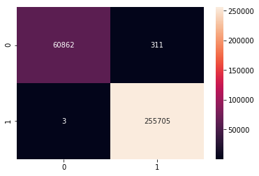

```python
cmm = cm(y_test, y_predicted)
cmm_logit = cmm
sns.heatmap(cmm, annot = True, fmt='g')
```

```python
print("Percentage of wrongly classified values:", 314/(60862+255705+314)*100,"%")
```

```
Percentage of wrongly classified values: 0.09909082589363198 %
```

It also gives us really promising results. Number of false positive and false negative values is marginal in comparison with correct values

# 4. Random Forest

Although the Logistic Regression conducted in previous chapter went in satisfying way it is not always the case when working with imabalanced dataset. One of the algorithms which are supposed to be more efficient in dealing with lack of balance in dataset is Random Forest which will be implemented in this chapter. In this case I will use GridSearchCv to choose best parameteres for Random Forest.

```python
from sklearn.ensemble import RandomForestClassifier
from sklearn.model_selection import GridSearchCV
```

```python
classifier = RandomForestClassifier(random_state=0)
```

To use a GridSearchCV it is important to specify some parameters which will be used with classifier

```python
grid_param = {
    'n_estimators': [10, 32, 64]
}
```

We will simplify the anlysis and limit parameters just to number of estimator. Our dataset is large and multiplying possible combinations might make our analysis much longer.

Number of estimators which means the number of trees is by default set to 10. The other values are literature based. Where it is suggested that the satisfying number of trees is between 64 - 128 and more are not necessary( The source is: https://www.researchgate.net/publication/230766603_How_Many_Trees_in_a_Random_Forest). However to make a computational process less demanding we will use 64 as a maximum value

About GridSearchCV itself we make it similar as cross validation in Logistic Regression. Scoring is set to be "roc_auc" and number of folds = 3

```python
grid_forest = GridSearchCV(estimator=classifier,
                     param_grid=grid_param,
                     scoring='roc_auc',
                     cv=3, verbose = 10)

grid_forest.fit(X_train, y_train)
```

```
Fitting 3 folds for each of 3 candidates, totalling 9 fits
```

```
[Parallel(n_jobs=1)]: Using backend SequentialBackend with 1 concurrent workers.
```

```
[CV] n_estimators=10 .................................................
[CV] ..................... n_estimators=10, score=0.999, total=  33.0s
[CV] n_estimators=10 .................................................
```

```
[Parallel(n_jobs=1)]: Done   1 out of   1 | elapsed:   33.0s remaining:    0.0s
```

```
[CV] ..................... n_estimators=10, score=0.999, total=  31.2s
[CV] n_estimators=10 .................................................
```

```
[Parallel(n_jobs=1)]: Done   2 out of   2 | elapsed:  1.1min remaining:    0.0s
```

```
[CV] ..................... n_estimators=10, score=0.999, total=  40.6s
[CV] n_estimators=32 .................................................
```

```
[Parallel(n_jobs=1)]: Done   3 out of   3 | elapsed:  1.7min remaining:    0.0s
```

```
[CV] ..................... n_estimators=32, score=1.000, total= 1.7min
[CV] n_estimators=32 .................................................
```

```
[Parallel(n_jobs=1)]: Done   4 out of   4 | elapsed:  3.4min remaining:    0.0s
```

```
[CV] ..................... n_estimators=32, score=1.000, total= 1.6min
[CV] n_estimators=32 .................................................
```

```
[Parallel(n_jobs=1)]: Done   5 out of   5 | elapsed:  5.0min remaining:    0.0s
```

```
[CV] ..................... n_estimators=32, score=1.000, total= 1.7min
[CV] n_estimators=64 .................................................
```

```
[Parallel(n_jobs=1)]: Done   6 out of   6 | elapsed:  6.6min remaining:    0.0s
```

```
[CV] ..................... n_estimators=64, score=1.000, total= 3.1min
[CV] n_estimators=64 .................................................
```

```
[Parallel(n_jobs=1)]: Done   7 out of   7 | elapsed:  9.7min remaining:    0.0s
```

```
[CV] ..................... n_estimators=64, score=1.000, total= 3.1min
[CV] n_estimators=64 .................................................
```

```
[Parallel(n_jobs=1)]: Done   8 out of   8 | elapsed: 12.8min remaining:    0.0s
```

```
[CV] ..................... n_estimators=64, score=1.000, total= 3.1min
```

```
[Parallel(n_jobs=1)]: Done   9 out of   9 | elapsed: 15.9min remaining:    0.0s
[Parallel(n_jobs=1)]: Done   9 out of   9 | elapsed: 15.9min finished
```

```
GridSearchCV(cv=3, error_score='raise-deprecating',
             estimator=RandomForestClassifier(bootstrap=True, class_weight=None,
                                              criterion='gini', max_depth=None,
                                              max_features='auto',
                                              max_leaf_nodes=None,
                                              min_impurity_decrease=0.0,
                                              min_impurity_split=None,
                                              min_samples_leaf=1,
                                              min_samples_split=2,
                                              min_weight_fraction_leaf=0.0,
                                              n_estimators='warn', n_jobs=None,
                                              oob_score=False, random_state=0,
                                              verbose=0, warm_start=False),
             iid='warn', n_jobs=None, param_grid={'n_estimators': [10, 32, 64]},
             pre_dispatch='2*n_jobs', refit=True, return_train_score=False,
             scoring='roc_auc', verbose=10)
```

```python
best_parameters = grid_forest.best_params_
print(best_parameters)

best_result = grid_forest.best_score_
print("Mean Area Under the Receiver Operating Characteristic Curve:", best_result)
```

```
{'n_estimators': 64}
Mean Area Under the Receiver Operating Characteristic Curve: 0.9997361613584306
```

```python
y_predicted = grid_forest.predict(X_test)
y_predicted_forest = y_predicted
```

```python
print("accuracy score:", accuracy_score(y_test, y_predicted))
```

```
accuracy score: 0.9969389139771713
```

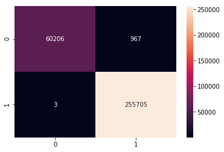

```python
cmm = cm(y_test, y_predicted)
cmm_forest = cmm
sns.heatmap(cmm, annot = True, fmt='g')
```

```python
print("Percentage of wrongly classified values:",970/(60206+255705+970)*100,"%")
```

```
Percentage of wrongly classified values: 0.3061086022828759 %
```

What might be surprising Random Forest did slightly **worse** than Logistic Regression with L2 penalty. Random Forest has a better ROC AUC score, however it is worse in the area of accuracy score and also it has a bigger percent of wrongly classified values. What should be said it is also much more computationally demanding.

# 5. Support Vector Machines

To use SVM, we need to normalize our variables.

```python
X_SVM = fin_data.loc[:, fin_data.columns != 'loan_status']
y_SVM = fin_data.loan_status

num_cols = list(X_SVM.columns[np.any([X_SVM.dtypes=="float64", X_SVM.dtypes=="int64"], axis=0)])

X_SVM[num_cols] = X_SVM[num_cols].apply(lambda x: (x-x.mean())/x.std())
y_SVM = (y_SVM=="Fully Paid").astype(int)
```

```python
X_train_SVM, X_test_SVM, y_train_SVM, y_test_SVM = train_test_split(X_SVM, y_SVM, test_size=0.3, random_state = 42)
```

```python
y_train_SVM = y_train_SVM.reset_index(drop=True)
X_train_SVM = X_train_SVM.reset_index(drop=True)
```

We will use three different types of kernels.

Firstly, we will use simple linear kernel. To reduce computing time, we will limit the number of samples for training to 2000.

```python
limit = 2000
kf = KFold(n_splits=5, random_state=42)
aucs = []
aucsT = []
clf = SVC(C=1, cache_size=500, kernel='linear',
    max_iter=-1, probability=True,
    tol=0.001, verbose=False)

for train, test in kf.split(X_train_SVM.index.values):
    X = X_train_SVM.iloc[train].sample(limit, random_state=42)
    clf.fit(X.values, y_train_SVM[X.index.values].values)
    prob = clf.predict_proba(X_train_SVM.iloc[test].values)

    aucs.append(metrics.roc_auc_score(y_train_SVM[test].values, prob[:,1]))

    prob = clf.predict_proba(X.values)
    aucsT.append(metrics.roc_auc_score(y_train_SVM[X.index.values].values, prob[:,1]))
```

```python
print("Mean AUC for Training: %.8f" % np.mean(aucsT))
print(np.round(aucsT, 8))
print("Mean AUC for Full Dataset: %.8f" % np.mean(aucs))
print(np.round(aucs, 8))
```

```
Mean AUC for Training: 0.99969776
[0.99898943 0.99961973 0.99987966 1.         1.        ]
Mean AUC for Full Dataset: 0.99906277
[0.99900598 0.99923467 0.99901363 0.99926909 0.9987905 ]
```

Now we will see if the polynominal kernel with degree 2 will improve the fit.

```python
limit = 2000
kf = KFold(n_splits=5, random_state=42)
aucs = []
aucsT = []
clf = SVC(C=1, cache_size=500, degree=2,kernel='poly',
    max_iter=-1, probability=True,
    tol=0.001, verbose=False, gamma='auto')

for train, test in kf.split(X_train_SVM.index.values):
    X = X_train_SVM.iloc[train].sample(limit, random_state=42)
    clf.fit(X.values, y_train_SVM[X.index.values].values)
    prob = clf.predict_proba(X_train_SVM.iloc[test].values)

    aucs.append(metrics.roc_auc_score(y_train_SVM[test].values, prob[:,1]))

    prob = clf.predict_proba(X.values)
    aucsT.append(metrics.roc_auc_score(y_train_SVM[X.index.values].values, prob[:,1]))
```

```python
print("Mean AUC for Training: %.8f" % np.mean(aucsT))
print(np.round(aucsT, 8))
print("Mean AUC for Full Dataset: %.8f" % np.mean(aucs))
print(np.round(aucs, 8))
```

```
Mean AUC for Training: 0.99889881
[0.99710789 0.99935103 0.99919246 0.9992426  0.99960006]
Mean AUC for Full Dataset: 0.99209440
[0.99141032 0.99305511 0.9924793  0.99156041 0.99196688]
```

Polynomial kernel probably is not a good fit for our data as it lowered the AUC score.

Lastly we will try the RBF kernel.

```python
limit = 2000
kf = KFold(n_splits=5, random_state=42)
aucs = []
aucsT = []
clf = SVC(C=1, cache_size=500, degree=3,kernel='rbf',
    max_iter=-1, probability=True,
    tol=0.001, verbose=False, gamma='scale')

for train, test in kf.split(X_train_SVM.index.values):
    X = X_train_SVM.iloc[train].sample(limit, random_state=42)
    clf.fit(X.values, y_train_SVM[X.index.values].values)
    prob = clf.predict_proba(X_train_SVM.iloc[test].values)

    aucs.append(metrics.roc_auc_score(y_train_SVM[test].values, prob[:,1]))

    prob = clf.predict_proba(X.values)
    aucsT.append(metrics.roc_auc_score(y_train_SVM[X.index.values].values, prob[:,1]))
```

```python
print("Mean AUC for Training: %.8f" % np.mean(aucsT))
print(np.round(aucsT, 8))
print("Mean AUC for Full Dataset: %.8f" % np.mean(aucs))
print(np.round(aucs, 8))
```

```
Mean AUC for Training: 0.99966053
[0.99854681 0.99987272 0.99991766 0.999978   0.99998745]
Mean AUC for Full Dataset: 0.99710582
[0.99608836 0.99745769 0.99736929 0.99743973 0.99717402]
```

```python
clf = SVC(C=1, cache_size=500, kernel='linear', max_iter=-1, probability=True, tol=0.001, verbose=False)
clf.fit(X_train_SVM.sample(limit, random_state=42).values, y_train_SVM.sample(limit, random_state=42).values)
```

```
SVC(C=1, cache_size=500, class_weight=None, coef0=0.0,
    decision_function_shape='ovr', degree=3, gamma='auto_deprecated',
    kernel='linear', max_iter=-1, probability=True, random_state=None,
    shrinking=True, tol=0.001, verbose=False)
```

Now we will see how our model is doing on the test set.

```python
probs = clf.predict_proba(X_test_SVM.values)[:,1]
y_predicted_SVM = probs>0.5
y_predicted_SVM = y_predicted_SVM.astype(int)
```

```python
print("accuracy score:", accuracy_score(y_test_SVM, y_predicted_SVM))
```

```
accuracy score: 0.98962070935146
```

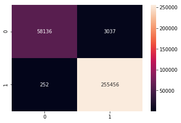

```python
cmm_svm = cm(y_test_SVM, y_predicted_SVM)
sns.heatmap(cmm_svm, annot = True, fmt='g')
```

```python
print("Percentage of wrongly classified values:",(cmm_svm[0][1]+cmm_svm[1][0])/(cmm_svm[0][0]+cmm_svm[0][1]+cmm_svm[1][1]+cmm_svm[1][0])*100,"%")
```

```
Percentage of wrongly classified values: 1.037929064853999 %
```

# 6. Model comparisons

In general, in credit risk we are interested in identifying defaulters and there is a bigger risk in falsely assessing someone is not a defaulter (false negative) than falsely identifying someone as a defaulter (false positive).

In our analysis, value 1 is actually not being a defaulter, so we will look at True Negative Rate first.

$$TNR = {TN \over N} = {TN \over FP+TN}$$

```python
def TNR(cmm):
    TP = cmm[1][1]
    FP = cmm[0][1]
    TN = cmm[0][0]
    FN = cmm[1][0]

    return 100*(TN/(FP+TN))

print("TNR logit: %.4f" % TNR(cmm_logit), "%", sep="")
print("TNR forest: %.4f" % TNR(cmm_forest), "%", sep="")
print("TNR SVM: %.4f" % TNR(cmm_svm), "%", sep="")
```

```
TNR logit: 99.4916%
TNR forest: 98.4192%
TNR SVM: 95.0354%
```

We can see that logit model gave the best results.

```python
def BACC(cmm):
    TP = cmm[1][1]
    FP = cmm[0][1]
    TN = cmm[0][0]
    FN = cmm[1][0]

    return 100/2*(TP/(TP+FP) + TN/(TN+FN))

print("BACC logit: %.4f" % BACC(cmm_logit), "%", sep="")
print("BACC forest: %.4f" % BACC(cmm_forest), "%", sep="")
print("BACC SVM: %.4f" % BACC(cmm_svm), "%", sep="")
```

```
BACC logit: 99.9368%
BACC forest: 99.8091%
BACC SVM: 99.1968%
```

Again, logit model is the most accurate model.

Additionally to the measures calculated above, we will also compare True Positive Rate.

$$ TPR = {TP \over P} = {TP \over TP+FN}$$

```python
def TPR(cmm):
    return 100*(cmm[1][1] / (cmm[1][1] + cmm[1][0]))
print("TPR logit: %.4f" % TPR(cmm_logit), "%", sep="")
print("TPR forest: %.4f" % TPR(cmm_forest), "%", sep="")
print("TPR SVM: %.4f" % TPR(cmm_svm), "%", sep="")
```

```
TPR logit: 99.9988%
TPR forest: 99.9988%
TPR SVM: 99.9015%
```

Here the best classification model seems to be logit and forest tree.

# 7. Summary

In all methods, we received unbelievably good results. This might be a sign for data leakage or maybe our variables contained information whether someone is a defaulter or not. Possible developments for this analysis would be to inspect whether the latter is actually the case.